# NYborough-covid

gntem2

01/05/2020

## Spatial regression

This is data published in Jama 29/4/2020 on COVD-19 in New York. The New York borough shapefiles were obtained from New York Open Data at https://data.cityofnewyork.us/City-Government/Borough-Boundaries/tqmj-j8zm. For those wishing to evaluate other datasets, there’s lung cancer data in SpatialEpi library, lip cancer, leukemia in DClusterm library. Key aspect of spatial regression is that neighbouring regions are similar and distant regions are less so. It uses the *polyn2nb* in *spdep* library to create the neighbourhood weight.

```r
library(SpatialEpi)
library(spdep)
```

```r
library(ggplot2)
library(tmap)
library(sf)
library(dplyr)
library(MASS)
library(here)
#data from jama paper
dfj<-data.frame(
Borough=c("Bronx","Brooklyn","Manhattan","Queens","Staten Island"),
Pop=c(1432132,2582830,1628701,2278906,476179),
Age65=c(12.8,13.9,16.5,15.7,16.2),
Income=c(38467,61220,85066,69320,82166),
Beds=c(336,214,534,144,234),
COVIDtest=c(4599,2970,2844,3800,5603),
COVIDhosp=c(634,400,331,560,370),
COVIDdeath=c(224,181,122,200,143),
COVIDdeathlab=c(173,132,91,154,117)
  ) %>%
  #reverse prevalence per 100000 to raw
  mutate(Age65raw=Age65/100000*Pop,
               Bedsraw=Beds/100000*Pop,
               COVIDtestraw=COVIDtest/100000*Pop,
               COVIDhospraw=COVIDhosp/100000*Pop,
               COVIDdeathraw=COVIDdeath/100000*Pop)
#Expected
rate<-sum(dfj$COVIDdeathraw)/sum(dfj$Pop)
dfj$Expected<-with(dfj, Pop*rate )
#SMR standardised mortality ratio
dfj$SMR<-with(dfj, COVIDdeathraw/Expected)
#NY Shape file

NYsf<-st_read("./Borough_Boundaries/geo_export_7d3b2726-20d8-4aa4-a41f-24ba74eb6bc0.shp")
NYsf<-left_join(NYsf, dfj,by=c("boro_name"="Borough"))


#contiguity based neighbourhood
NY.nb<-poly2nb(NYsf)
is.symmetric.nb(NY.nb) # TRUE
```

```
## [1] TRUE
```

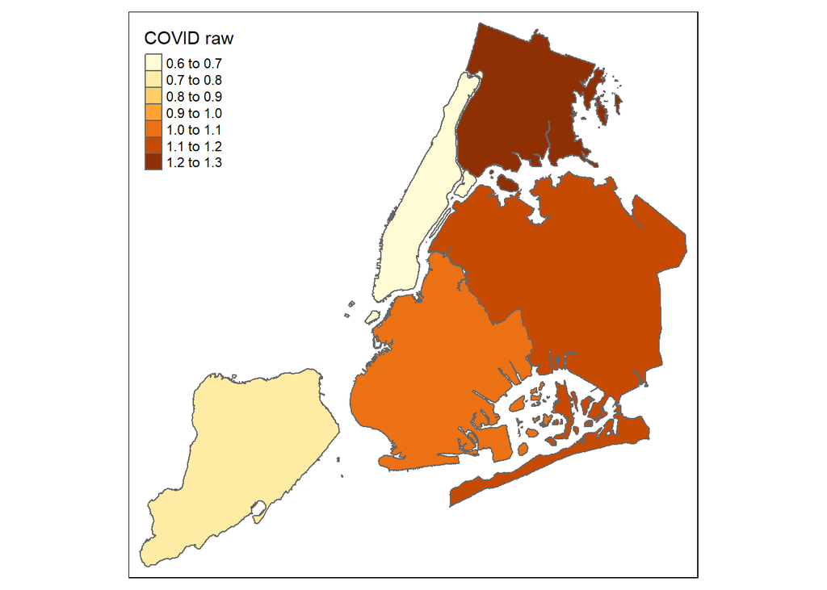

```r
#raw data
tm_shape(NYsf) + tm_polygons(col='SMR',title='COVID raw')
```

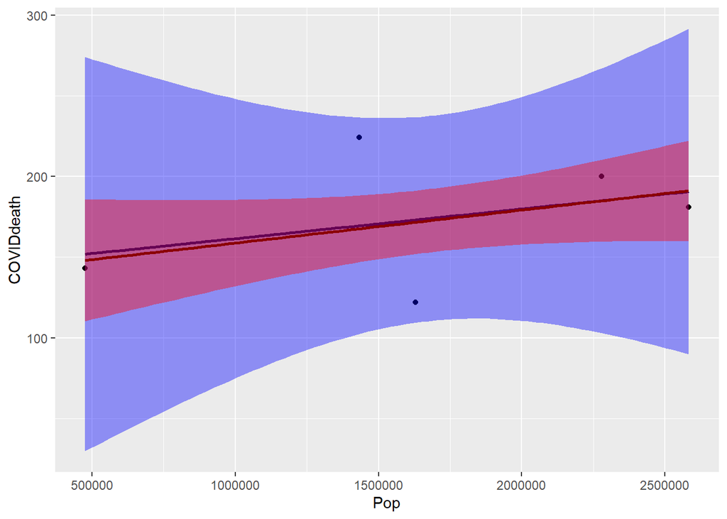

```r
#plot regression lines linear vs robust linear
ggplot(data=NYsf,aes(x=Pop,y=COVIDdeath)) + geom_point() + geom_smooth(method='lm',col='darkblue',fill='blue') + geom_smooth(method='rlm',col='darkred',fill='red')
```

```r
#robust linear models
NYsf$resids <- rlm(COVIDdeathraw~Pop+Age65raw,data=NYsf)$res
#tmap robust linear model-residual
tm_shape(NYsf) + tm_polygons(col='resids',title='Residuals')+tm_style("col_blind")
```

```
## Variable "resids" contains positive and negative values, so midpoint is set to 0. Set midpoint = NA to show the full spectrum of the color palette.
```

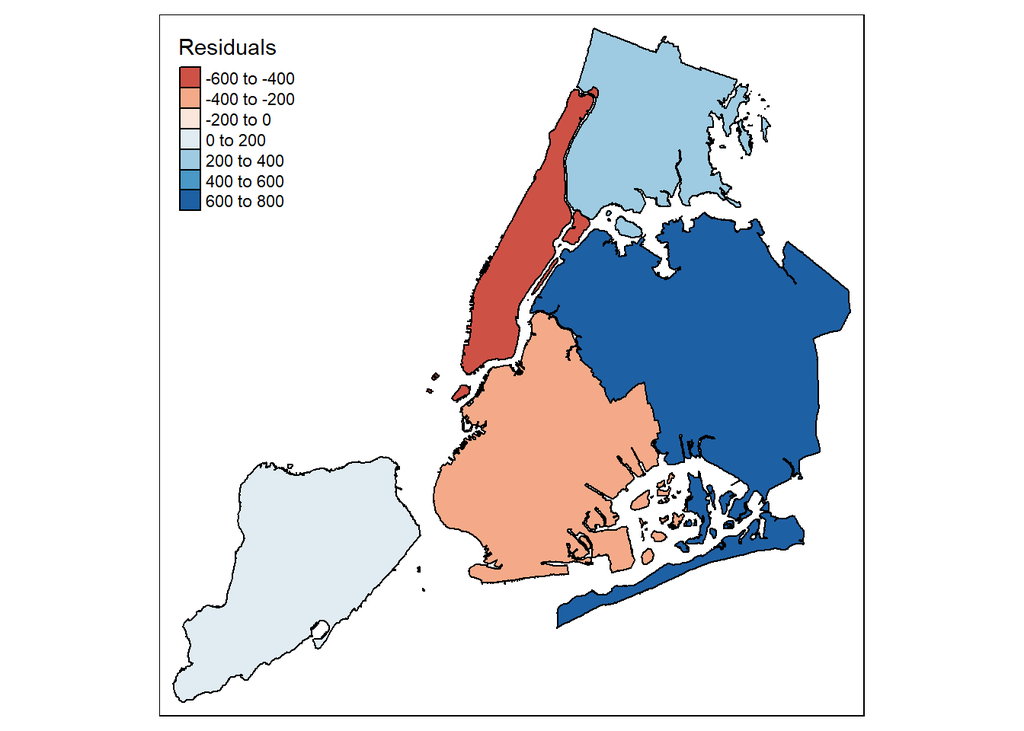

```r
rescale <- function(x) (x - mean(x))/(quantile(x,0.975) - quantile(x,0.025))
#create spatial weights for neibour lists
r.id<-attr(NYsf,"region.id")
lw <- nb2listw(NY.nb,zero.policy = TRUE) #W=row standardised
#spatial autocorrelation
moran.test(NYsf$SMR,listw = lw , na.action = na.omit, zero.policy = T)
```

```
##
##  Moran I test under randomisation
##
## data:  NYsf$SMR
## weights: lw  n reduced by no-neighbour observations
##
##
## Moran I statistic standard deviate = 0.12105, p-value = 0.4518
## alternative hypothesis: greater
## sample estimates:
## Moran I statistic       Expectation          Variance
##       -0.31006289       -0.33333333        0.03695269
```

This section uses Bayesian modeling for regression with fitting of the model by INLA.https://www.r-bloggers.com/spatial-data-analysis-with-inla/. For those wanting to analyse leukemia in New York instead of COVID-19, the dataset *NY8* is available from *DClusterm*.

```r
library(spdep)
library(INLA)
```

```r
nb2INLA("NY.graph", NY.nb)
#This create a file called ``LDN-INLA.adj'' with the graph for INLA
NY.adj <- paste(getwd(),"/NY.graph",sep="")
#Poisson model with no random latent effect-ideal baseline model
m1<-inla(COVIDdeathraw~ 1+Age65raw+Income+Beds+COVIDhospraw, data=NYsf, family="poisson",
         E=NYsf$Expected,control.predictor = list(compute = TRUE),
  control.compute = list(dic = TRUE, waic = TRUE) )
R1<-summary(m1)
```

```r
#Poisson model with random effect
#index to identify random effect ID
NYsf$ID <- 1:nrow(NYsf)
m2<-inla(COVIDdeathraw~ 1+Age65raw+Income+Beds+COVIDhospraw +f(ID, model = "iid"), data=NYsf, family="poisson",
         E=NYsf$Expected,control.predictor = list(compute = TRUE),
  control.compute = list(dic = TRUE, waic = TRUE) )
R2<-summary(m2)
NYsf$FIXED.EFF <- m1$summary.fitted[, "mean"]
NYsf$IID.EFF <- m2$summary.fitted[, "mean"]

#plot regression on map
tSMR<-tm_shape(NYsf)+tm_polygons("SMR")
tFIXED<-tm_shape(NYsf)+tm_polygons("FIXED.EFF")
tIID<-tm_shape(NYsf)+tm_polygons("IID.EFF")
```

This next paragraph involves the use of spatial random effects in regression models. Examples include conditional autoregressive (CAR) and intrinsic CAR (ICAR)

```r
# Create sparse adjacency matrix
NY.mat <- as(nb2mat(NY.nb, style = "B",zero.policy = TRUE), "Matrix") #S=variance stabilise
# Fit model
m.icar <- inla(COVIDdeathraw ~ 1 +Age65raw+Income+Beds+COVIDhospraw+
    f(ID, model = "besag", graph = NY.mat),
  data = NYsf, E = NYsf$Expected, family ="poisson",
  control.predictor = list(compute = TRUE),
  control.compute = list(dic = TRUE, waic = TRUE))
R3<-summary(m.icar)
```

The Besag-York-Mollie (BYM) now accounts for spatial dependency of neighbours.

```r
m.bym = inla(COVIDdeathraw ~ 1+Age65raw+Income+Beds+COVIDhospraw +
    f(ID, model = "bym", graph = NY.mat),
  data = NYsf, E = NYsf$Expected, family ="poisson",
  control.predictor = list(compute = TRUE),
  control.compute = list(dic = TRUE, waic = TRUE))
R4<-summary(m.bym)
```

```r
ICARmatrix <- Diagonal(nrow(NY.mat), apply(NY.mat, 1, sum)) - NY.mat
Cmatrix <- Diagonal(nrow(NYsf), 1) -  ICARmatrix
max(eigen(Cmatrix)$values)
```

```
## [1] 1
```

```r
m.ler = inla(COVIDdeathraw ~ 1 +Age65raw+Income+Beds+COVIDhospraw+
    f(ID, model = "generic1", Cmatrix = Cmatrix),
  data = NYsf, E = NYsf$Expected, family ="poisson",
  control.predictor = list(compute = TRUE),
  control.compute = list(dic = TRUE, waic = TRUE))
R5<-summary(m.ler)
```

Spatial econometric model

```r
#X
mmatrix <- model.matrix(COVIDdeathraw ~ 1, NYsf)

#W
W <- as(nb2mat(NY.nb, style = "W", zero.policy = TRUE), "Matrix")

#Q
Q.beta = Diagonal(n = ncol(mmatrix), x = 0.001)

#Range of rho
rho.min<- -1
rho.max<- 1

#Arguments for 'slm'
args.slm = list(
   rho.min = rho.min ,
   rho.max = rho.max,
   W = W,
   X = mmatrix,
   Q.beta = Q.beta
)

#Prior on rho
hyper.slm = list(
   prec = list(
      prior = "loggamma", param = c(0.01, 0.01)),
      rho = list(initial=0, prior = "logitbeta", param = c(1,1))
)

#SLM model
m.slm <- inla( COVIDdeathraw ~ -1+Age65raw+Income+Beds+COVIDhospraw +
     f(ID, model = "slm", args.slm = args.slm, hyper = hyper.slm),
   data = NYsf, family = "poisson",
   E = NYsf$Expected,
   control.predictor = list(compute = TRUE),
   control.compute = list(dic = TRUE, waic = TRUE)
)
R6<-summary(m.slm)

marg.rho.internal <- m.slm$marginals.hyperpar[["Rho for ID"]]
marg.rho <- inla.tmarginal( function(x) {
  rho.min + x * (rho.max - rho.min)
}, marg.rho.internal)

inla.zmarginal(marg.rho, FALSE)
```

```
## Mean            -0.00248836
## Stdev           0.544869
## Quantile  0.025 -0.923817
## Quantile  0.25  -0.476863
## Quantile  0.5   0.0230952
## Quantile  0.75  0.470005
## Quantile  0.975 0.872928
```

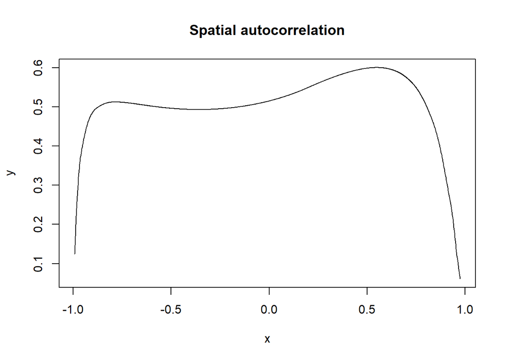

```r
plot(marg.rho, type = "l", main = "Spatial autocorrelation")
```

Model selection

```r
NYsf$ICAR <- m.icar$summary.fitted.values[, "mean"]
NYsf$BYM <- m.bym$summary.fitted.values[, "mean"]
NYsf$LEROUX <- m.ler$summary.fitted.values[, "mean"]
NYsf$SLM <- m.slm$summary.fitted.values[, "mean"]

labels<-c("Fixed","IID", "ICAR","BYM","LEROUX","SLM")
Marginal_Likelihood<-c(R1$mlik[1],R2$mlik[1],R3$mlik[1],R4$mlik[1],R5$mlik[1],R6$mlik[1])
Marginal_Likelihood<-round(Marginal_Likelihood,2)
WAIC<-c(R1$waic[[1]],R2$waic[[1]],R3$waic[[1]],R4$waic[[1]],R5$waic[[1]],R6$waic[[1]])
WAIC<-round(WAIC,2)
DIC<-c(R1$dic[[1]],R2$dic[[1]],R3$dic[[1]],R4$dic[[1]],R5$dic[[1]],R6$dic[[1]])
DIC<-round(DIC,2)
Results<-data.frame(labels,Marginal_Likelihood,WAIC,DIC)
knitr::kable(Results)
```

| labels | Marginal_Likelihood | WAIC | DIC |
| --- | --- | --- | --- |
| Fixed | -57.97 | -0.73 | 0.8 |
| IID | -57.97 | -0.73 | 0.8 |
| ICAR | -53.04 | -0.73 | 0.8 |
| BYM | -49.08 | -0.73 | 0.8 |
| LEROUX | -57.69 | -0.73 | 0.8 |
| SLM | -64.75 | -0.73 | 0.8 |

```r
#plot maps
tICAR<-tm_shape(NYsf)+tm_polygons("ICAR")
tBYM<-tm_shape(NYsf)+tm_polygons("BYM")
tLEROUX<-tm_shape(NYsf)+tm_polygons("LEROUX")
tSLM<-tm_shape(NYsf)+tm_polygons("SLM")
#arrange in grid using tmap arrange
current.mode <- tmap_mode("plot")
```

```
## tmap mode set to plotting
```

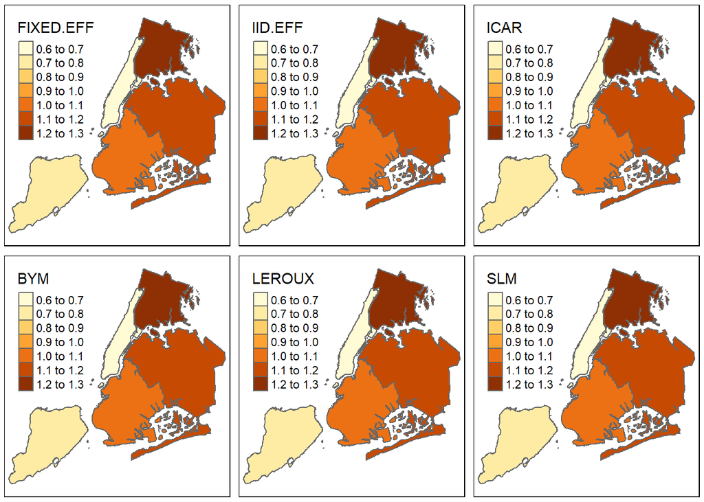

```r
tmap_arrange(tFIXED,tIID,tICAR,tBYM,tLEROUX,tSLM)
```

```r
tmap_mode(current.mode)
```

```
## tmap mode set to plotting
```